# Forecasting for Stocks and Crypto

Joshua Weimer

1/1/2022

## Intro

I’ve been a hobby investor for many years, but recently I’ve been curios to combine my data science skills with my interest in finance and financial markets. In this document I will outline some of the forecasting methods I use to predict price movements in both cryptocurrencies and stocks, as well as the APIs I use to get financial data. These strategies are used in my automated trading strategies I’m developing which can be viewed [at my github](https://github.com/jjweimer/robinhood)

## Data Collection

Good data is extremely important for any forecasting project. Fortunately, the quantmod and RobinHood packages make it extremely easy to gather financial data. Quantmod allows the user to access the yahoo finance API, whereas the RobinHood package allows for RobinHood API access. Note that the Robinhood API requires an account through the RobinHood brokerage.

```r
library(quantmod)
library(RobinHood)
```

With packages loaded we can collect financial data through the Robinhood API. I’ll start by getting 5 years of Apple’s ($AAPL) trading data.

```r
AAPL <- get_historicals(RH,
                        'AAPL',
                        interval = 'day',
                        span = '5year')
```

And now, a simple plot of the data. AAPL stock had a good run over the past 5 years, so I’ll visualize it in green

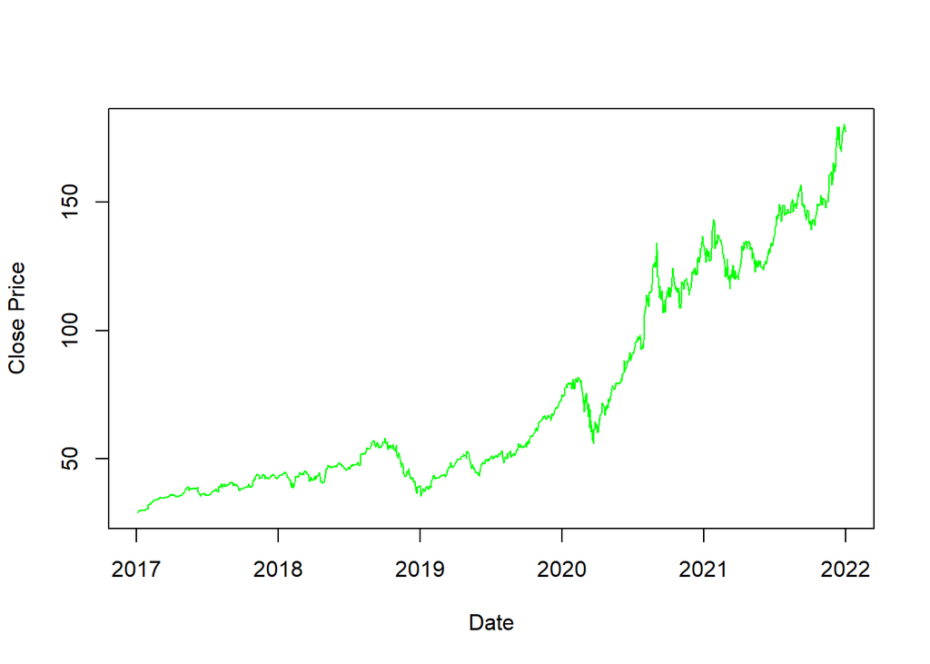

```r
plot(AAPL$begins_at, AAPL$close_price,
     type="l",
     col = 'green',
     xlab = "Date",
     ylab = "Close Price")
```

## Forecasting

Now that we have data, we can try to make a forecast. For forecasting I use two primary techniques: ARIMA modeling and Prophet modeling.

### ARIMA

ARIMA models are univariate time series models which use auto-regressive (AR) terms and Moving Averages (MA) to find relationships between observations in a time series. Most simply, this model will use correlations (ACF) and partial correlations (PACF) of our close price data to predict future prices. Optimal ARIMA models are very easy to generate in R using the ‘forecast’ package.

```r
library(forecast)
```

With our library loaded in, I’ll build an ARIMA model and forecast the next 90 days of AAPL’s price movement

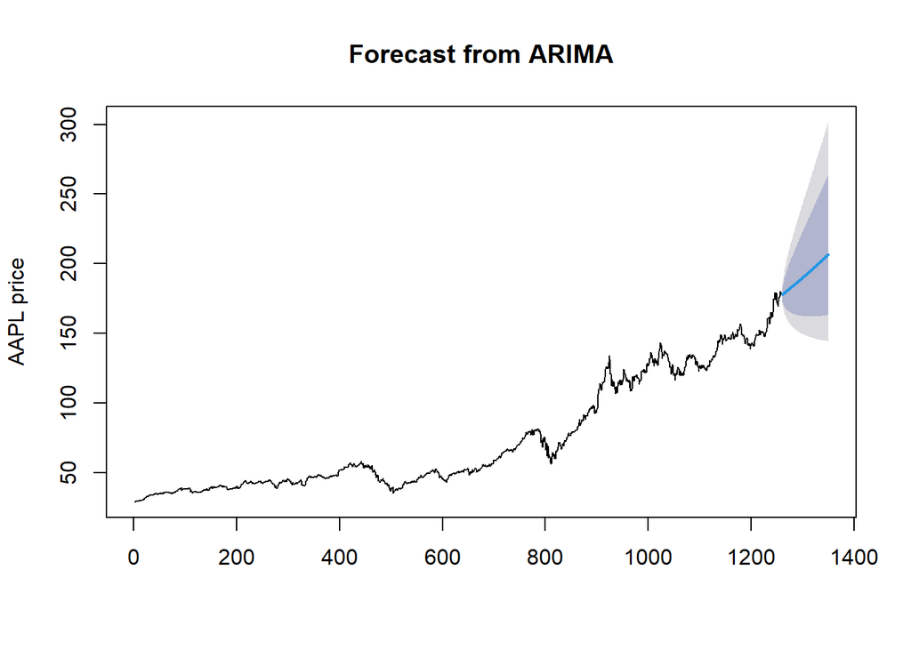

```r
AAPL_arima <- auto.arima(AAPL$close_price, lambda = "auto")

#forecasting
AAPL_arima_forecast <- forecast(AAPL_arima, h = 90)

#plot the forecast
plot(AAPL_arima_forecast,
     main = 'Forecast from ARIMA',
     ylab = 'AAPL price')
```

The model predicts upward price movement for AAPL in the next 90 days. The dark and light grey bands represent an 80% and 95% confidence interval respectively.

### Prophet

Prophet is a time series forecasting method developed by the Facebook Data Science Team. The prophet forecast combines a piece wise linear trend, seasonal effects, and holiday effects.

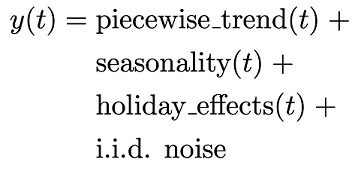

We can utilize prophet forecasting using the aptly named ‘prophet’ package

```r
library(prophet)
```

Let’s see how the prophet model performs on our AAPL stock example

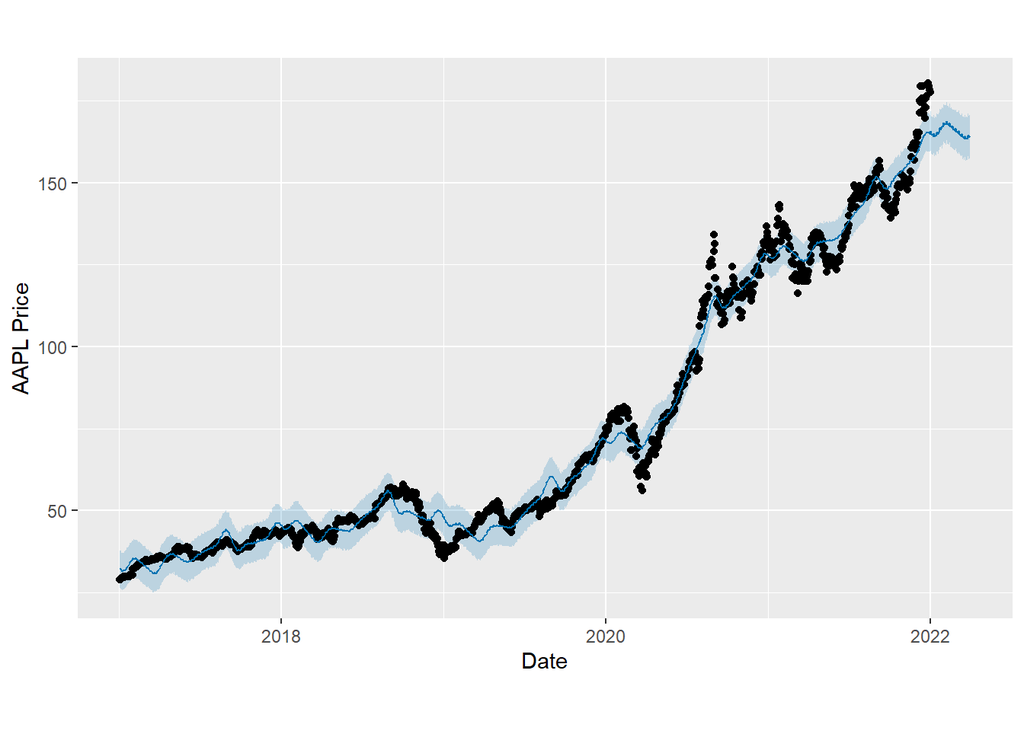

```r
#We convert dataset as prophet input requires
df <- data.frame(ds = AAPL$begins_at,
                 y = AAPL$close_price)

#prophet model application
x <- prophet(df) # x
future <- make_future_dataframe(x, periods = 90)
fcst <- predict(x, future) #fcst

plot(x, fcst,
     xlab = 'Date',
     ylab = 'AAPL Price',
     main = 'Prophet Forecast')
```

In this plot, the black dots represent actual observations of AAPL close price. The blue curve is the prophet model, and the bands are the confidence interval. Prophet’s use of piecewise linear trends usually result in more actionable forecasts than ARIMA models when dealing with volatility. For an example, we can turn to crypto.

### ARIMA vs Prophet for Volatile securities

First, we’ll get a month of bitcoin price data from Robinhood at the hour interval

```r
BTC_data <- get_historicals_crypto(RH,
                                 'BTC',
                                 interval = 'hour',
                                 span = 'month',
                                 bounds = '24_7')
```

Next, we’ll convert the data and apply a prophet model to forecast the next 4 days of price movement

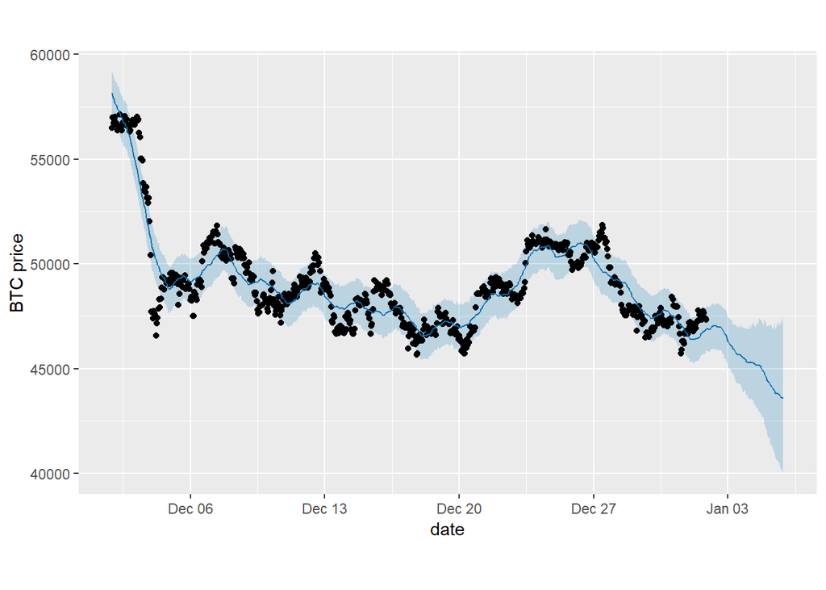

```r
BTC <- data.frame(ds = BTC_data$begins_at,
                  y = BTC_data$close_price)

#make prophet model
m <- prophet(BTC)
future <- make_future_dataframe(m, periods = 24*4, freq = 60 * 60)
fcst <- predict(m, future)

plot(m, fcst, main = 'BTC price forescast',
     ylab = 'BTC price',
     xlab = 'date')
```

The prophet model predicts downwards price movement for Bitcoin over the next four days. The model fit is able to capture the shorter term peaks and valleys in price as well as the month long downward trend. Let’s compare this to an ARIMA forecast

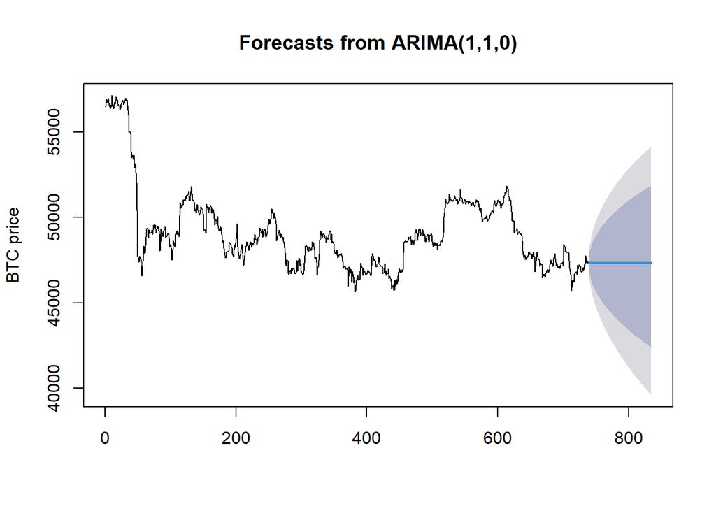

```r
BTC_data$close_price<- as.numeric(BTC_data$close_price)
BTC_arima <- auto.arima(BTC_data$close_price[1:738], lambda = "auto")

#forecasting
BTC_arima_forecast <- forecast(BTC_arima, h = 96) #4 days = 96hrs

#plot the forecast
plot(BTC_arima_forecast,
     ylab = 'BTC price')
```

As we can see, the ARIMA has a much harder time with this data. The primary reason for this can be seen in the model’s correlgrams. Since the model has a d value of 1, this indicates that data is stationary with differencing of 1 applied. Also, since we have a p value of 1, this indicates that our auto regressive term has lag 1.

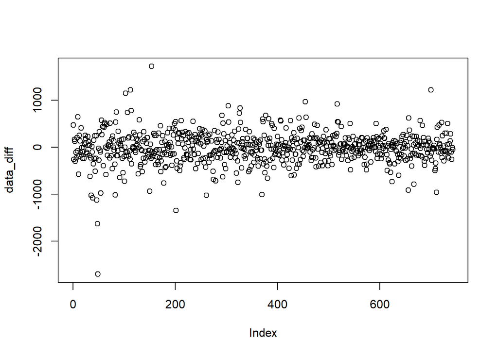

```r
library(tseries)

#difference the data once
data_diff <- diff(BTC_data$close_price)

#vizually check the data is stationary
plot(data_diff)
```

```r
##ADF test to ensure data is stationary
adf_diff <- adf.test(data_diff,
                alternative = c("stationary", "explosive"),
                k = 0)
adf_diff
```

```
##
##  Augmented Dickey-Fuller Test
##
## data:  data_diff
## Dickey-Fuller = -25.455, Lag order = 0, p-value = 0.01
## alternative hypothesis: stationary
```

Vizually, we can see the data is stationary. This is confirmed by our ADF test which returns a p value of 0.01. Now with the data differenced, let’s look at the ACF and PACF of the given model

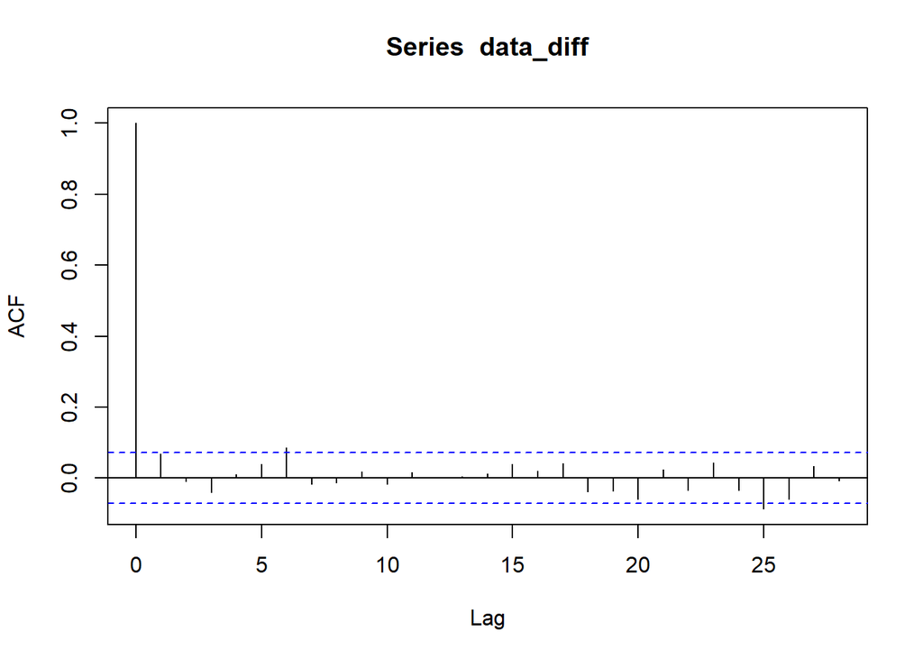

```r
acf(data_diff)
```

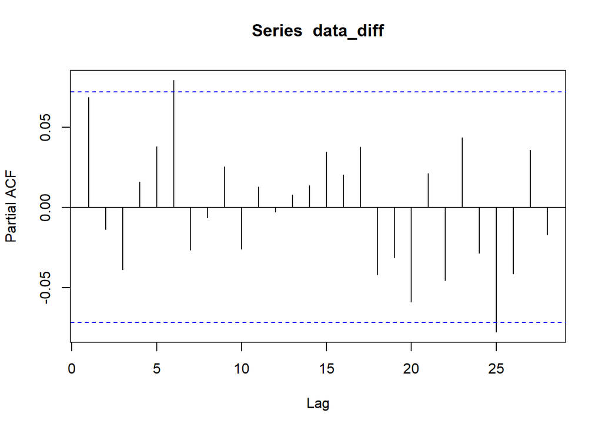

```r
pacf(data_diff)
```

## Conclusion

ARIMA and prophet models are both useful time series analysis tools for forecasting price movements in the financial world. Understanding the methodology behind the tools as well as the strengths and weaknesses of each can help to better forecast price movements and make intelligent trading decisions.